# College Majors_4º_Visualization_Plots

```
Basic earnings and labour force info of grads from 2010-2012
```

```python
import pandas as pd
import matplotlib.pyplot as plt
%matplotlib inline
```

#### Reading the DataSet *recent-grads.csv*, and returning its first row:

```python
recent_grads = pd.read_csv('recent-grads.csv')
recent_grads.iloc[0]
```

```
Rank                                        1
Major_code                               2419
Major                   PETROLEUM ENGINEERING
Total                                    2339
Men                                      2057
Women                                     282
Major_category                    Engineering
ShareWomen                           0.120564
Sample_size                                36
Employed                                 1976
Full_time                                1849
Part_time                                 270
Full_time_year_round                     1207
Unemployed                                 37
Unemployment_rate                   0.0183805
Median                                 110000
P25th                                   95000
P75th                                  125000
College_jobs                             1534
Non_college_jobs                          364
Low_wage_jobs                             193
Name: 0, dtype: object
```

#### Top 5 Majors by median earnings:

```python
recent_grads.head()
```

|  | Rank | Major_code | Major | Total | Men | Women | Major_category | ShareWomen | Sample_size | Employed | ... | Part_time | Full_time_year_round | Unemployed | Unemployment_rate | Median | P25th | P75th | College_jobs | Non_college_jobs | Low_wage_jobs |
| --- | --- | --- | --- | --- | --- | --- | --- | --- | --- | --- | --- | --- | --- | --- | --- | --- | --- | --- | --- | --- | --- |
| 0 | 1 | 2419 | PETROLEUM ENGINEERING | 2339.0 | 2057.0 | 282.0 | Engineering | 0.120564 | 36 | 1976 | ... | 270 | 1207 | 37 | 0.018381 | 110000 | 95000 | 125000 | 1534 | 364 | 193 |
| 1 | 2 | 2416 | MINING AND MINERAL ENGINEERING | 756.0 | 679.0 | 77.0 | Engineering | 0.101852 | 7 | 640 | ... | 170 | 388 | 85 | 0.117241 | 75000 | 55000 | 90000 | 350 | 257 | 50 |
| 2 | 3 | 2415 | METALLURGICAL ENGINEERING | 856.0 | 725.0 | 131.0 | Engineering | 0.153037 | 3 | 648 | ... | 133 | 340 | 16 | 0.024096 | 73000 | 50000 | 105000 | 456 | 176 | 0 |
| 3 | 4 | 2417 | NAVAL ARCHITECTURE AND MARINE ENGINEERING | 1258.0 | 1123.0 | 135.0 | Engineering | 0.107313 | 16 | 758 | ... | 150 | 692 | 40 | 0.050125 | 70000 | 43000 | 80000 | 529 | 102 | 0 |
| 4 | 5 | 2405 | CHEMICAL ENGINEERING | 32260.0 | 21239.0 | 11021.0 | Engineering | 0.341631 | 289 | 25694 | ... | 5180 | 16697 | 1672 | 0.061098 | 65000 | 50000 | 75000 | 18314 | 4440 | 972 |

5 rows × 21 columns

#### Bottom 5 Majors by median earnings:

```python
recent_grads.tail()
```

|  | Rank | Major_code | Major | Total | Men | Women | Major_category | ShareWomen | Sample_size | Employed | ... | Part_time | Full_time_year_round | Unemployed | Unemployment_rate | Median | P25th | P75th | College_jobs | Non_college_jobs | Low_wage_jobs |
| --- | --- | --- | --- | --- | --- | --- | --- | --- | --- | --- | --- | --- | --- | --- | --- | --- | --- | --- | --- | --- | --- |
| 168 | 169 | 3609 | ZOOLOGY | 8409.0 | 3050.0 | 5359.0 | Biology & Life Science | 0.637293 | 47 | 6259 | ... | 2190 | 3602 | 304 | 0.046320 | 26000 | 20000 | 39000 | 2771 | 2947 | 743 |
| 169 | 170 | 5201 | EDUCATIONAL PSYCHOLOGY | 2854.0 | 522.0 | 2332.0 | Psychology & Social Work | 0.817099 | 7 | 2125 | ... | 572 | 1211 | 148 | 0.065112 | 25000 | 24000 | 34000 | 1488 | 615 | 82 |
| 170 | 171 | 5202 | CLINICAL PSYCHOLOGY | 2838.0 | 568.0 | 2270.0 | Psychology & Social Work | 0.799859 | 13 | 2101 | ... | 648 | 1293 | 368 | 0.149048 | 25000 | 25000 | 40000 | 986 | 870 | 622 |
| 171 | 172 | 5203 | COUNSELING PSYCHOLOGY | 4626.0 | 931.0 | 3695.0 | Psychology & Social Work | 0.798746 | 21 | 3777 | ... | 965 | 2738 | 214 | 0.053621 | 23400 | 19200 | 26000 | 2403 | 1245 | 308 |
| 172 | 173 | 3501 | LIBRARY SCIENCE | 1098.0 | 134.0 | 964.0 | Education | 0.877960 | 2 | 742 | ... | 237 | 410 | 87 | 0.104946 | 22000 | 20000 | 22000 | 288 | 338 | 192 |

5 rows × 21 columns

### We can immediately visualize 2 major trends:

[output not shown]

#### A descriptive analysis of the DataSet:

```python
recent_grads.describe(include='all')
```

|  | Rank | Major_code | Major | Total | Men | Women | Major_category | ShareWomen | Sample_size | Employed | ... | Part_time | Full_time_year_round | Unemployed | Unemployment_rate | Median | P25th | P75th | College_jobs | Non_college_jobs | Low_wage_jobs |
| --- | --- | --- | --- | --- | --- | --- | --- | --- | --- | --- | --- | --- | --- | --- | --- | --- | --- | --- | --- | --- | --- |
| count | 173.000000 | 173.000000 | 173 | 172.000000 | 172.000000 | 172.000000 | 173 | 172.000000 | 173.000000 | 173.000000 | ... | 173.000000 | 173.000000 | 173.000000 | 173.000000 | 173.000000 | 173.000000 | 173.000000 | 173.000000 | 173.000000 | 173.000000 |
| unique | NaN | NaN | 173 | NaN | NaN | NaN | 16 | NaN | NaN | NaN | ... | NaN | NaN | NaN | NaN | NaN | NaN | NaN | NaN | NaN | NaN |
| top | NaN | NaN | ECOLOGY | NaN | NaN | NaN | Engineering | NaN | NaN | NaN | ... | NaN | NaN | NaN | NaN | NaN | NaN | NaN | NaN | NaN | NaN |
| freq | NaN | NaN | 1 | NaN | NaN | NaN | 29 | NaN | NaN | NaN | ... | NaN | NaN | NaN | NaN | NaN | NaN | NaN | NaN | NaN | NaN |
| mean | 87.000000 | 3879.815029 | NaN | 39370.081395 | 16723.406977 | 22646.674419 | NaN | 0.522223 | 356.080925 | 31192.763006 | ... | 8832.398844 | 19694.427746 | 2416.329480 | 0.068191 | 40151.445087 | 29501.445087 | 51494.219653 | 12322.635838 | 13284.497110 | 3859.017341 |
| std | 50.084928 | 1687.753140 | NaN | 63483.491009 | 28122.433474 | 41057.330740 | NaN | 0.231205 | 618.361022 | 50675.002241 | ... | 14648.179473 | 33160.941514 | 4112.803148 | 0.030331 | 11470.181802 | 9166.005235 | 14906.279740 | 21299.868863 | 23789.655363 | 6944.998579 |
| min | 1.000000 | 1100.000000 | NaN | 124.000000 | 119.000000 | 0.000000 | NaN | 0.000000 | 2.000000 | 0.000000 | ... | 0.000000 | 111.000000 | 0.000000 | 0.000000 | 22000.000000 | 18500.000000 | 22000.000000 | 0.000000 | 0.000000 | 0.000000 |
| 25% | 44.000000 | 2403.000000 | NaN | 4549.750000 | 2177.500000 | 1778.250000 | NaN | 0.336026 | 39.000000 | 3608.000000 | ... | 1030.000000 | 2453.000000 | 304.000000 | 0.050306 | 33000.000000 | 24000.000000 | 42000.000000 | 1675.000000 | 1591.000000 | 340.000000 |
| 50% | 87.000000 | 3608.000000 | NaN | 15104.000000 | 5434.000000 | 8386.500000 | NaN | 0.534024 | 130.000000 | 11797.000000 | ... | 3299.000000 | 7413.000000 | 893.000000 | 0.067961 | 36000.000000 | 27000.000000 | 47000.000000 | 4390.000000 | 4595.000000 | 1231.000000 |
| 75% | 130.000000 | 5503.000000 | NaN | 38909.750000 | 14631.000000 | 22553.750000 | NaN | 0.703299 | 338.000000 | 31433.000000 | ... | 9948.000000 | 16891.000000 | 2393.000000 | 0.087557 | 45000.000000 | 33000.000000 | 60000.000000 | 14444.000000 | 11783.000000 | 3466.000000 |
| max | 173.000000 | 6403.000000 | NaN | 393735.000000 | 173809.000000 | 307087.000000 | NaN | 0.968954 | 4212.000000 | 307933.000000 | ... | 115172.000000 | 199897.000000 | 28169.000000 | 0.177226 | 110000.000000 | 95000.000000 | 125000.000000 | 151643.000000 | 148395.000000 | 48207.000000 |

11 rows × 21 columns

### On avg only a very small sample of the grads are Unemployed, 2.416.

### The maximum Median wage is of 110.000 per year (*Major in PETROLEUM ENGINEERING*). While the minimum Median Wage is of 22.000 per year (*Major in LIBRARY SCIENCE*).

#### Cleaning our DataSet and removing the rows with NaN values in order to pass columns in Matplotlib with matching values so that no erros occur:

```python
raw_data_count = recent_grads.shape[0]
print(raw_data_count)
```

```
173
```

```python
recent_grads.dropna(axis=0, inplace=True)
```

```python
cleaned_data_count = recent_grads.shape[0]
print(cleaned_data_count)
```

```
172
```

#### Only 1 row was dropped from the original DataSet. Meaning that only 1 row in the entire DataSet had missing values! We now have 172 rows instead of the original 173!

#### Generating some Scatters plots:

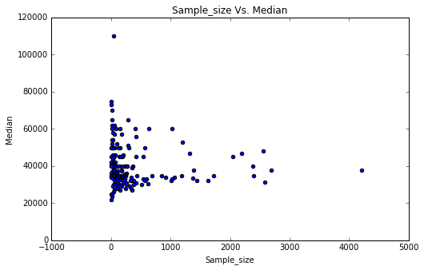

```python
recent_grads.plot(x='Sample_size', y='Median', kind='scatter', title='Sample_size Vs. Median', figsize=(8,5))
```

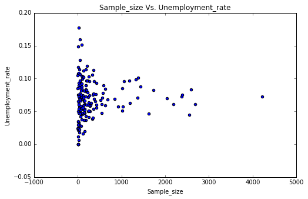

```python
recent_grads.plot(x='Sample_size', y='Unemployment_rate', kind='scatter', title='Sample_size Vs. Unemployment_rate', figsize=(8,5))
```

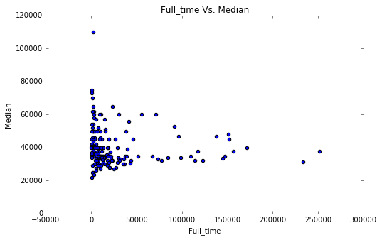

```python
recent_grads.plot(x='Full_time', y='Median', kind='scatter', title='Full_time Vs. Median', figsize=(8,5))
```

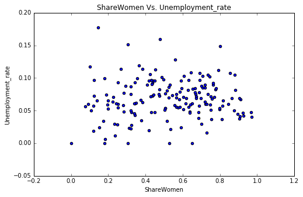

```python
recent_grads.plot(x='ShareWomen', y='Unemployment_rate', kind='scatter', title='ShareWomen Vs. Unemployment_rate', figsize=(8,5))
```

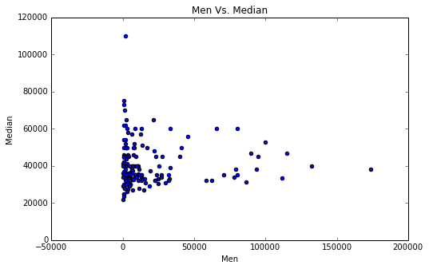

```python
recent_grads.plot(x='Men', y='Median', kind='scatter', title='Men Vs. Median', figsize=(8,5))
```

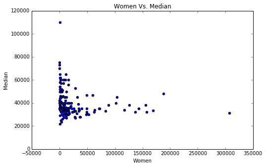

```python
recent_grads.plot(x='Women', y='Median', kind='scatter', title='Women Vs. Median', figsize=(8,5))
```

### There is no positive relation between the most popular majors and the amount of money students make! What we can observe is that the majority of the less popular majors grant the students a paycheck bellow 40k per year. Other not so popular majors, in a very less percentage, grant students an annual salary of 60k.

### The majority of majors that are populated by women are situated bellow the 60k income per year, with a focus around the 40k per year.

### Observations in women above an income of 60k per year are very scarce and limited to very few examples!

### The majors that are most popular among women all fall under 60k per year!

### It seems there is no obvious link between the number of full-time employees and the median salary.

### Apart from that we can tell that the majors were the number of full-time employees is low is were the most obsvervations between a median salary of 20k-40k per year are observed.

### We should also pinpoint the lack of positive relation between the number of students in full-time jobs and their median salary per year. We should be led to think that way, but in reality that doesn't happen!

#### Generating some Histogram plots:

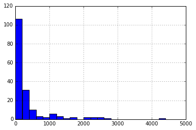

```python
recent_grads['Sample_size'].hist(bins=25, range=(0,5000))
```

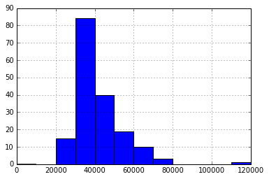

```python
recent_grads['Median'].hist(bins=12, range=(0,120000))
```

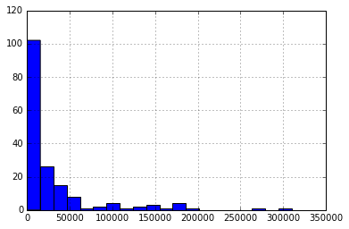

```python
recent_grads['Employed'].hist(bins=20, range=(0,310000))
```

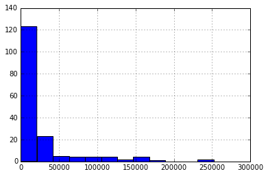

```python
recent_grads['Full_time'].hist(bins=12, range=(0,252000))
```

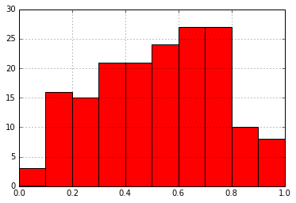

```python
recent_grads['ShareWomen'].hist(bins=10, range=(0,1), color='red')
```

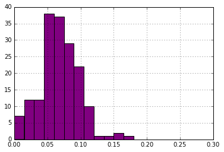

```python
recent_grads['Unemployment_rate'].hist(bins=20, range=(0,0.3), color='purple')
```

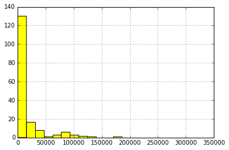

```python
recent_grads['Men'].hist(bins=20, range=(0,310000), color='yellow')
```

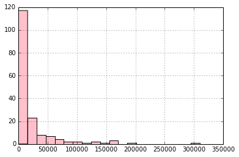

```python
recent_grads['Women'].hist(bins=20, range=(0,310000), color='pink')
```

#### Another way of plotting all these histograms, but writing far less code, resorting to a for loop:

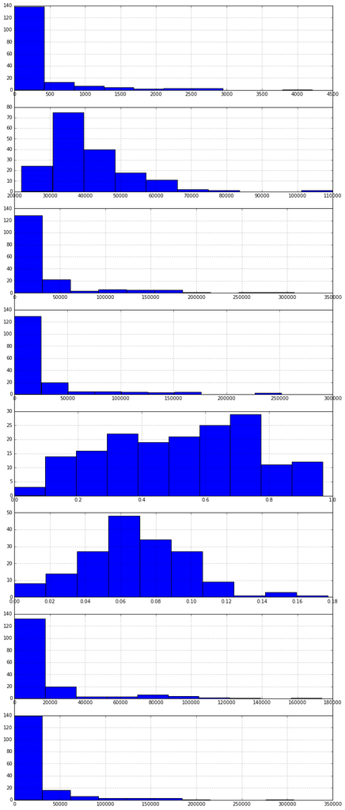

```python
cols = ['Sample_size', 'Median', 'Employed', 'Full_time', 'ShareWomen', 'Unemployment_rate', 'Men', 'Women']

fig, ax = plt.subplots(figsize=(12,30))
plt.xticks([])
plt.yticks([])


for i in range(8):
    ax = fig.add_subplot(8,1,i+1)
    ax = recent_grads[cols[i]].hist(bins=10)
```

### The most commom median salary is observed in the range between 30k and 40k per year!

### Its fair to say that more than half of all majors (96 Majors/56%) have a percentage of more than 50% of women based on the *ShareWomen* histogram. While men control the other 76 Majors, arround 44%.

```python
from pandas.plotting import scatter_matrix
```

```
array([[<matplotlib.axes._subplots.AxesSubplot object at 0x7f61c2869160>,
      dtype=object)
```

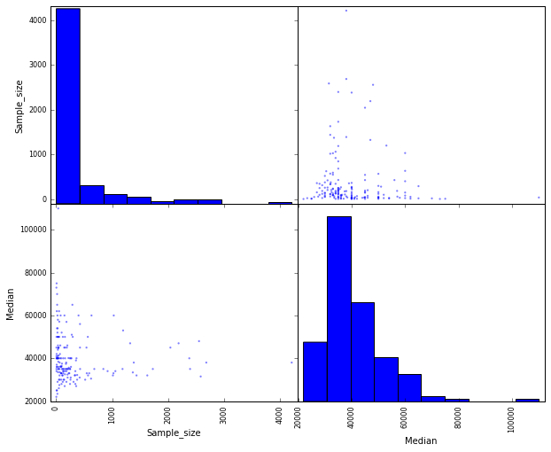

```python
scatter_matrix(recent_grads[['Sample_size', 'Median']], figsize=(10,8))
```

### We can observe a relation between the median salary and the sample size. Low sample sized majors are more common in the median salary range of 20k-40k

```
array([[<matplotlib.axes._subplots.AxesSubplot object at 0x7f61c2207b00>,
      dtype=object)
```

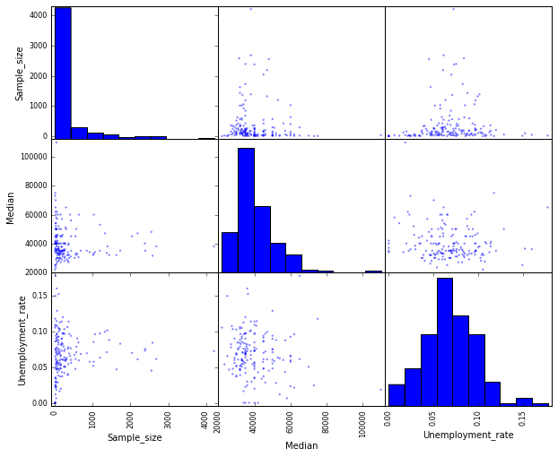

```python
scatter_matrix(recent_grads[['Sample_size', 'Median', 'Unemployment_rate']],
             figsize=(10,8))
```

### The frequency of ocurrences in the Unemployment_rate is higher between 5%-10%. This is also the interval were we see more cases of median salary bellow 40k per year!

#### Using some bar plots to compare the percentages of women and also of the Unemployment rate in all the Majors, from the top and bottom 10:

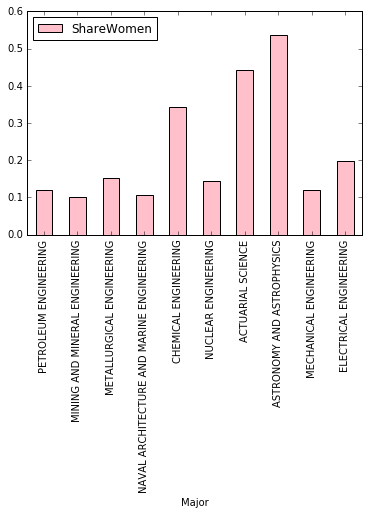

```python
recent_grads[:10].plot.bar(x='Major',y='ShareWomen' ,rot=90, color='pink')
```

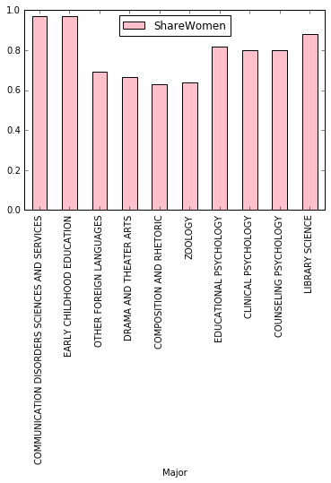

```python
recent_grads.tail(10).plot.bar(x='Major', y='ShareWomen', rot=90, color='pink')
```

### Its interesting to see that the percentage of women is much higher in the Majors that return a lower median income per year than the ones that pay considerably better! The exception is seen only in one Major, *Astronomy and Astrophysics*. Being this the only Major that figures in the top 10 of the most well paid were women are predominante!

### Another interesting fact is that all the top 10 paying Majors are Engineerings or very technical ones, and the bottom 10 is composed by social/art/language sciences. In fact, this attests what we´ve already concluded in the first steps of this analysis.

### Are men more pron to numbers/engineerings than women? Are women more pron to social/art/languages than men? Or is this a stigma/prejudice of a macho society thats pushing women to supposedly women orientated Majors that brings them a lower income compared to others dominated by men?

### What the numbers do tell us is that women, although being predominants in the majority of all Majors (56%) are the ones integrating the majority of the lower income ones, and therefore receiving a far lower median income than men!

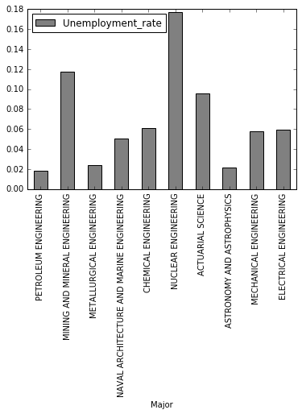

```python
recent_grads.head(10).plot.bar(x='Major', y='Unemployment_rate', color='grey')
```

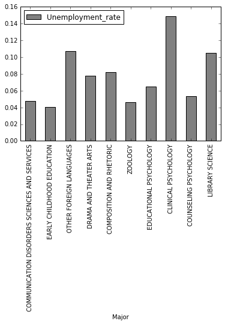

```python
recent_grads[162:].plot.bar(x='Major', y='Unemployment_rate', color='grey')
```

### Unemployment rates are slightly higher in the bottom 10 Majors. Despite that, the biggest Unemployment rate is seen in 1 Major of the top 10, *Nuclear Engineering*, with approximetely 18% of Unemployment rate!

#### Exploring in a more depth the relation between *Men*, *Women* and their number in each category of Majors:

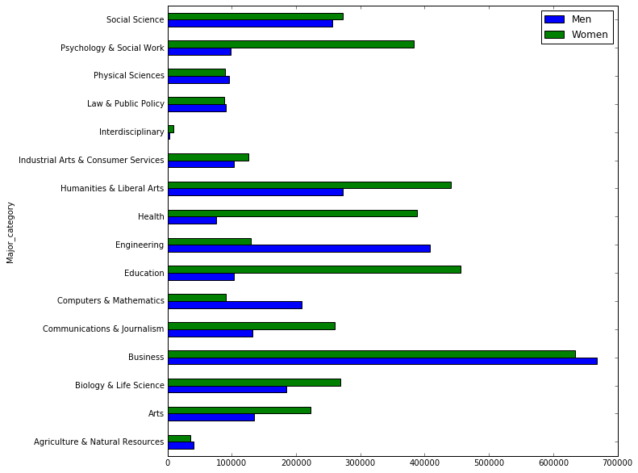

```python
recent_grads.groupby('Major_category')['Men', 'Women'].agg('sum').plot.barh(figsize=(10,10))
```

### As we previously concluded the disparity in *Engineering*, between women and men, is gigantic! This gap, although not in such proportion, can also be seen in the Major category *Computers & Mathematics* !

### The opposite is easily seen in areas like *Psychology & Social Work*, *Education*, *Arts* and *Humanities*!

#### Plotting 2 box plots to explore the distributions of median salaries and unemployment rate:

```
(0, 120000)
```

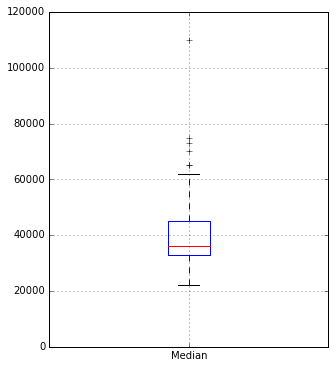

```python
recent_grads.boxplot(column=['Median'], figsize=(5,6))
plt.ylim(0,120000)
```

### Half of the values in the *Median* column (median salaries) are concentrated in a very small range, around 35k-45k.

### The range of the top 25% of the distribution of values is much higher (45k-61k) than the bottom 25% (21k-32k). This means that the lower incomes are more concentrated in a smaller range!

### It's also visible the existence of some outliers in the very high side. That may have influenced positively our *Median* mean and might explain the rather slight difference towards its median value, 40k Vs. 37k.

```
(-0.03, 0.19)
```

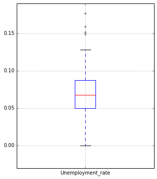

```python
recent_grads.boxplot(column='Unemployment_rate', figsize=(5,6))
plt.ylim(-0.03, 0.19)
```

### 50% of the values in the *Unemployment_rate* col are distributed around 5% and 8% rates!

### The distribution of values in this indicator is pretty even. No quartile ranges significantly different from other!

### The median value of the *Unemployment_rate* is around 7%!